# StatisticsAndSeaborn

# grade vs price

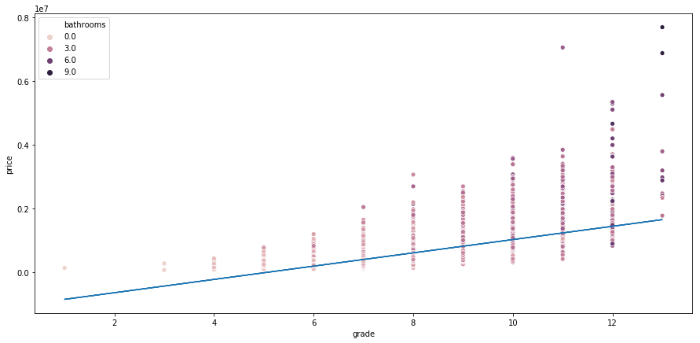

```python
xax = 'grade'
yax = 'price'
X = df[xax].values.reshape(-1, 1)
y = df[yax].values
reg = lm.fit(X, y )

fig, ax = plt.subplots(figsize=(15,7))
ax = sns.scatterplot(x=xax, y=yax, data=df, hue = 'bathrooms', sizes = 1)
plt.plot(X , reg.coef_ * X + reg.intercept_)
plt.show()
```

# price vs grade * sqft_living

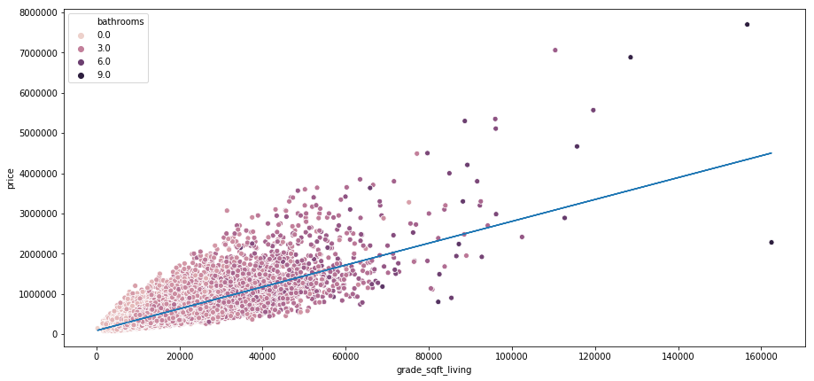

```python
xax = 'grade_sqft_living'
yax = 'price'
X = df[xax].values.reshape(-1, 1)
y = df[yax].values
reg = lm.fit(X, y )

fig, ax = plt.subplots(figsize=(15,7))
ax = sns.scatterplot(x=xax, y=yax, data=df, hue = 'bathrooms', sizes = 1)
plt.plot(X , reg.coef_ * X + reg.intercept_)
plt.show()
```

# sqft vs. grade

```python
corr_matrix = df.corr()
corr_matrix['sqft_living'].sort_values(ascending=False)
```

```
sqft_living          1.000000
grade_sqft_living    0.973735
sqft_above           0.876539
room_size            0.803230
grade                0.762880
sqft_living15        0.756513
bathrooms            0.754583
price                0.702311
bedrooms             0.576491
sqft_basement        0.434785
floors               0.354209
view                 0.284526
perks                0.282019
sqft_lot15           0.183372
sqft_lot             0.172929
waterfront           0.103883
condition           -0.058706
age                 -0.318574
Name: sqft_living, dtype: float64
```

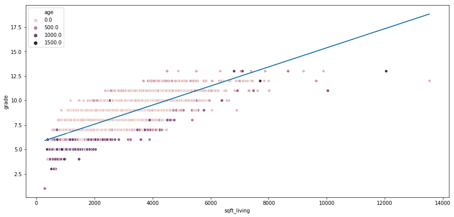

```python
xax = 'sqft_living'
yax = 'grade'
X = df[xax].values.reshape(-1, 1)
y = df[yax].values
reg = lm.fit(X, y )

fig, ax = plt.subplots(figsize=(15,7))
ax = sns.scatterplot(x=xax, y=yax, data=df, hue = 'age', sizes = 1)
plt.plot(X , reg.coef_ * X + reg.intercept_)
plt.show()
```

# Perks

I would suppose that if a house has more views and is waterfront property than it should be more expensive than those with fewer. The perks column attempts to analyze this info. The number of views range from 0 to 4 and I assume waterfront is either 0 for false or 1 for true. When we plot the price per perk we see the positive correlation. However, I am surprised still to see so many homes with a lot of perks with low prices.

At this point we can use our line of regression along with the categorization of the homes into number of perks to analyze samples of the entire dataset to see what makes these homes price differently. This process could be carried out similarly with any other variable E.g. why are homes of the same size priced differently, I suspect your conclusion would be similar to this example of perks.

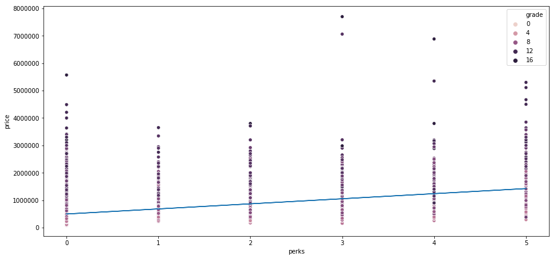

```python
xax = 'perks'
yax = 'price'

X = df[xax].values.reshape(-1, 1)
y = df[yax].values
reg = lm.fit(X, y )

fig, ax = plt.subplots(figsize=(15,7))
ax = sns.scatterplot(x=xax, y=yax, data=df, hue = 'grade', sizes = 1)
plt.plot(X , reg.coef_ * X + reg.intercept_)
plt.show()
```

To explain this plot further. We see 6 groups of data ranging from those with 0 perks i.e. no views and not waterfront, to 4 perks, homes that have max views but not waterfront and lastly waterfront homes with max views. The trend line shows that as the number of perks goes up so to does price. Now we can ask questions like why are some homes priced below the trend line. We may hypothesize that houses with a particular number of perks with a price below the line of regression may be more likely to be of low grade.

Furthermore is this statement true in general, for all home or does this assertion only hold true for a particular group of homes.

```python
perks = 3

#lets look at relevant data
#you can always do df[condition] to look at data where condition is true
data = df[df.perks == perks]
data_below = df[(df.perks == perks) & (df.price <  (reg.coef_* perks + reg.intercept_)[0])]
data_above = df[(df.perks == perks) & (df.price >= (reg.coef_* perks + reg.intercept_)[0])]
```

You can think of this in a simpler notation df[(condition1) & (condition2)] So what this is going to do is pull out data where both condition1 and condition2 are met.

condition1 condition2 result

```
T          T              T      ---->  get this data

F          T              F      |

T          F              F      |---> don't get this data

F          F              F      |
```

df[df.perks == perks] gives you every row and column of data where the value is equal to perks, which is what we assign at the top. That's why I called this dataframe data, because it contains all of the info.

df[(df.perks == perks) & (df.price < (reg.coef* perks + reg.intercept)[0])] pulls data from the original dataframe named df where perks = perks and price is below the line of regresion we know that it's data below the line of regression because that is what the value (reg.coef* perks + reg.intercept)[0]) is.

Just to explain futher the following data frames are equivalent.

data = df[(df.perks == perks) & (df.price < (reg.coef* perks + reg.intercept)[0])]

and

data = df[df.perks == perks] data = data[data.price < (reg.coef* perks + reg.intercept)[0]]

Because data is already the data where perks are say 5 so from that dataframe all you need to specify is the price you are interested in. I just wrote it the way I did, because I was thinking of the original df at the time, but everywhere you see df[(df.perks == perks) & (df.price < (reg.coef* perks + reg.intercept)[0])] you could replace it with data[df.price < (reg.coef* perks + reg.intercept)[0]] and it would do the same thing. In fact I did this later on in creating the dataframe before the bar charts.

This cell also prints out the avg of the data below and above. Showing you the means of each group.

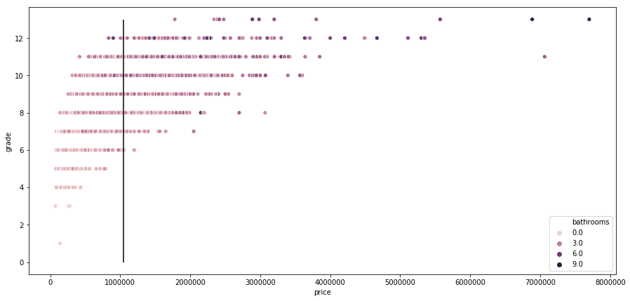

```
Avg below: 8.14 Avg above: 9.91 Ttest_indResult(statistic=17.266451390605095, pvalue=1.1239804095555982e-52)
```

```python
xax = 'price'
yax = 'grade'

fig, ax = plt.subplots(figsize=(15,7))
ax = sns.scatterplot(x=xax, y=yax, data=df, hue = 'bathrooms', sizes = 1)

#draw a vertical line where the trend predicts the value
plt.vlines(reg.coef_* perks + reg.intercept_, ymin = 0, ymax = 13)

plt.show()

print('Avg below:', round(data_below['grade'].mean(), 2),\
      'Avg above:', round(data_above['grade'].mean(), 2),\
      stats.ttest_ind(data_above['grade'], data_below['grade']))
```

```python
reg.coef_* perks + reg.intercept_
```

```
array([1051988.34592872])
```

df.corr()['price'].sort_values(ascending = False)

and observing that there is a positive correlation of 0.66 for grade. However, now that we are looking at samples in the data we are going to pick out stronger and weaker correlations than the 0.66 we saw before because the homes are different!

This shows that trends seen in samples of various sizes can also show up in larger sample sizes. But don't be surprised if you see samples of data within a dataset not behave as the bulk of the data does. Because nothing is stopping us from hand picking houses that show will show a negative correlation.

```python
stats.ttest_ind(data_above['grade'], data_below['grade'])
```

```
Ttest_indResult(statistic=17.266451390605095, pvalue=1.1239804095555982e-52)
```

```python
#This is how we pull the t score out of the result.
stats.ttest_ind(data_above['grade'], data_below['grade'])[0]
```

```
17.266451390605095
```

```python
#The index [1] tells you which value we're pulling from the result.
#Rember there's no difference between 0 and 6.190304649575503e-21.
stats.ttest_ind(data_above['grade'], data_below['grade'])[1]
```

```
1.1239804095555982e-52
```

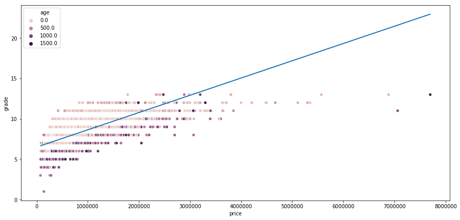

```
Avg below: 7.1 Avg above: 8.29 Ttest_indResult(statistic=86.55653179536166, pvalue=0.0)
```

```python
perks = 0

data = df[df.perks == perks]
data_below = data[data.price <  (reg.coef_* perks + reg.intercept_)[0]]
data_above = data[data.price >= (reg.coef_* perks + reg.intercept_)[0]]

xax = 'price'
yax = 'grade'

lm = LinearRegression()
X = df[xax].values.reshape(-1, 1)
y = df[yax].values
reg = lm.fit(X, y )

fig, ax = plt.subplots(figsize=(15,7))
ax = sns.scatterplot(x=xax, y=yax, data=df, hue = 'age', sizes = 1)
plt.plot(X , reg.coef_ * X + reg.intercept_)
plt.show()

print('Avg below:', round(data_below['grade'].mean(), 2),\
      'Avg above:', round(data_above['grade'].mean(), 2),\
      stats.ttest_ind(data_above['grade'], data_below['grade']))
```

A ttest is designed to tell you if results from a study are generalizable. For example if I take a sample of data from 30 people with two groups A and B. If the mean of group A is different from group B, can I conclude that from a sample of 3 thousand people the same will be true, that the mean of the respective groups will have the same proportion?

To answer this question we need to know how similar groups A and B are, that is what the t score tells you. The higher the t score value the greater the difference is between the groups, which means the conclusion is more generalizable.

In our case+ we are selecting a sample of the data based on the number of perks. Then we are dividing this sample in to two groups by price relative to the predicted price of our linear regression model. We are then comparing the means of these two groups using the ttest. We can then compare the means of each sample based on the perk value. What we will see is that the ttest becomes more conclusive the larger the sample size becomes.

If you are comparing two homes that have the same amenities/access/perks and one is more expensive than the other than the one that is more expensive is of higher grade.

In this example our,

Null Hypothesis: No statistical difference between the grade of homes priced above the trend line than those below the trend line.

But, our p-value is less than 0.05 which is by most standards, the critical p value yours must be lower than in order to reject the null hypothesis. So we reject the null hypothesis, if you reject the null hypothesis the alternate hypothesis is accepted.

Alternate Hypothesis: There is a difference in grade value between homes above and below the trend line. In a more precise language, there is a difference in the distribution of grades relative to price, among the two groups. The groups being chosen to be above or below our model prediction.

```python
#Here is how you would get the values without the for loop.
xax = 'perks'
yax = 'price'

lm = LinearRegression()
X = df[xax].values.reshape(-1, 1)
y = df[yax].values
reg = lm.fit(X, y )


perks = 2
data = df[df.perks == perks]
data_below = data[data.price <  (reg.coef_* perks + reg.intercept_)[0]]
data_above = data[data.price >= (reg.coef_* perks + reg.intercept_)[0]]
stats.ttest_ind(data_above['grade'], data_below['grade'])

t_score = stats.ttest_ind(data_above['grade'], data_below['grade'])[0]

p_value = stats.ttest_ind(data_above['grade'], data_below['grade'])[1]
```

You could visulaize the difference in the distribution of grades above and below the trend line, this would be more work to make it look right. But below is the idea. Below is how pandas groupby function works. It's like the .describe() atrribute of dataframes.

```python
xax = 'perks'
yax = 'price'

lm = LinearRegression()
X = df[xax].values.reshape(-1, 1)
y = df[yax].values
reg = lm.fit(X, y )

perks = 5
data = df[df.perks == perks]
data_below = data[data.price <  (reg.coef_* perks + reg.intercept_)[0]]
data_above = data[data.price >= (reg.coef_* perks + reg.intercept_)[0]]

#s1 and s2 is just the data above and below grouped by grade and counted!
s1 = pd.Series(data = data_above.groupby('grade')['price'].count(), name = 'Price Above')
s2 = pd.Series(data = data_below.groupby('grade')['price'].count(), name = 'Price Below')

#this puts together a dataframe called bar_data
bar_data = pd.concat([s1 , s2], axis = 1)
```

So this plot shows you the distribution of homes of a given grade with the number of perks specified above. For example, if you enter perks = 5, you'll see that just about the same number of homes are in both groups, but the median for each group is not the same. For perks = 2, it is clear that there are more homes priced below our models prediction, but the mean is still less than houses priced higher.

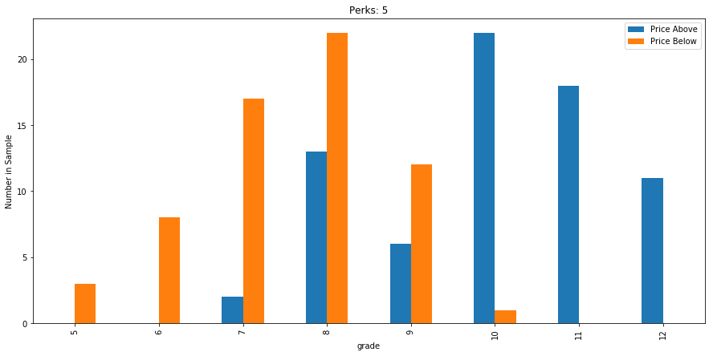

```python
fig, ax = plt.subplots(figsize = (15,7))
bar_data.plot.bar(ax = ax)
plt.ylabel('Number in Sample')
plt.title('Perks: '+ str(perks))
plt.show()
```

You can tell directly the biases of the grade value by looking at the correlation matrix. As you can see age has a -0.447 correlation to grade. So old houses on average were given worse grades.

```python
df.corr()['grade'].sort_values(ascending = False)
```

```
grade                1.000000
grade_sqft_living    0.848042
sqft_living          0.762880
sqft_above           0.756124
sqft_living15        0.713549
price                0.667755
bathrooms            0.664959
room_size            0.576555
floors               0.457964
bedrooms             0.357016
view                 0.251353
perks                0.248179
sqft_basement        0.168113
sqft_lot15           0.119417
sqft_lot             0.113794
waterfront           0.082847
condition           -0.144463
age                 -0.447159
Name: grade, dtype: float64
```

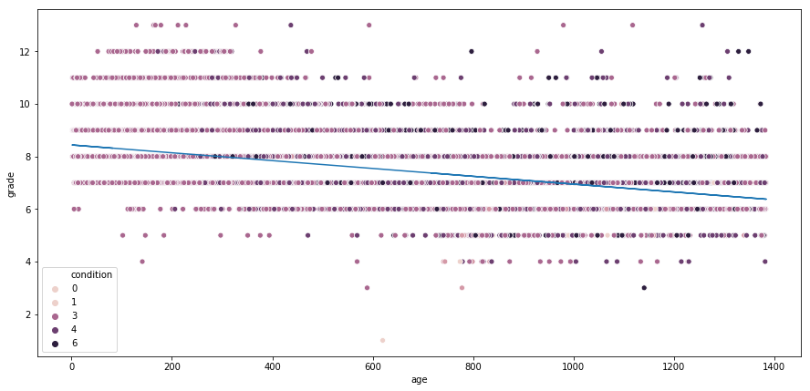

```python
'''
Here you can see the negative correlation.
'''

xax = 'age'
yax = 'grade'

lm = LinearRegression()
X = df[xax].values.reshape(-1, 1)
y = df[yax].values
reg = lm.fit(X, y )

fig, ax = plt.subplots(figsize=(15,7))
ax = sns.scatterplot(x=xax, y=yax, data=df, hue = 'condition', sizes = 1)
plt.plot(X , reg.coef_ * X + reg.intercept_)
plt.show()
```

# Price vs Condition

The distribution of prices among condition values appears to be close to a normal ditribution so whoever was assigning this value gave it fairly, regardless of price.

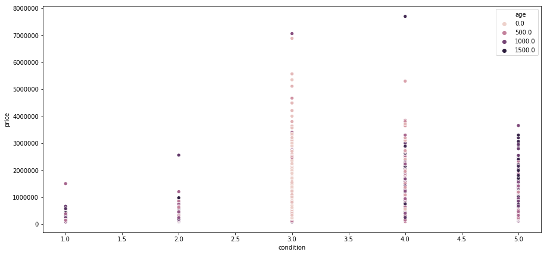

```python
xax = 'condition'
yax = 'price'

fig, ax = plt.subplots(figsize=(15,7))
ax = sns.scatterplot(x=xax, y=yax, data=df, hue = 'age', sizes = 1)
plt.show()
```

```python
'''
This is another example of using df.corr()['column name'] to get correlation values
the ascending = False puts in least to greatest form.
'''
df.corr()['grade'].sort_values(ascending = False)
```

```
grade                1.000000
grade_sqft_living    0.848042
sqft_living          0.762880
sqft_above           0.756124
sqft_living15        0.713549
price                0.667755
bathrooms            0.664959
room_size            0.576555
floors               0.457964
bedrooms             0.357016
view                 0.251353
perks                0.248179
sqft_basement        0.168113
sqft_lot15           0.119417
sqft_lot             0.113794
waterfront           0.082847
condition           -0.144463
age                 -0.447159
Name: grade, dtype: float64
```

As we might expect condition is most correlated to age. What's interesting though is that as age increases so to does condition. That makes me wonder what the condition value might measure! I would assume old homes are in worse condition so then the condition metric goes from 0 ->5 from worst-> best. In this way we can use our analysis of the data to deduce the meaning of the metrics of whatever survey this came from.

When you say technically I assume that you're professor told you this? That the condition value is a reflection of the physical state of the house? I agree that this would make since, but the data doesn't lie my friends.

```python
df.corr()['condition'].sort_values(ascending = False)
```

```
condition            1.000000
age                  0.360582
sqft_basement        0.174234
view                 0.045962
perks                0.045540
price                0.036299
bedrooms             0.028434
room_size            0.019932
waterfront           0.016622
sqft_lot15          -0.003506
sqft_lot            -0.009061
sqft_living         -0.058706
grade_sqft_living   -0.084870
sqft_living15       -0.092933
bathrooms           -0.124896
grade               -0.144463
sqft_above          -0.158229
floors              -0.263488
Name: condition, dtype: float64
```

The normal distribution of price vs. condition, explains the appearence of the linear regression on this data. the y-intercept is at 3 becasue that is how most homes are scored at age zero. The correlation between age and condition can still be seen as the age goes up so to does the condition. The fact that new homes are ranked a three also suggests some kind of artificial normalization!

Think about it. Why would new homes be ranked in the middle of some 'condition' points system? It makes no sense. Brand new homes have the ability to be better conditioned or worse conditioned? Figuring out what this condition column is measuring would be a good find.

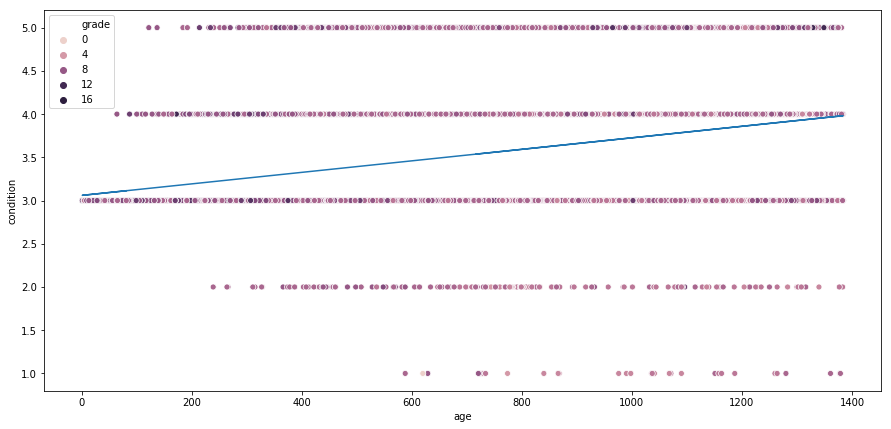

```python
xax = 'age'
yax = 'condition'

lm = LinearRegression()
X = df[xax].values.reshape(-1, 1)
y = df[yax].values
reg = lm.fit(X, y )

fig, ax = plt.subplots(figsize=(15,7))
ax = sns.scatterplot(x=xax, y=yax, data=df, hue = 'grade', sizes = 1)
plt.plot(X , reg.coef_ * X + reg.intercept_)
plt.show()
```

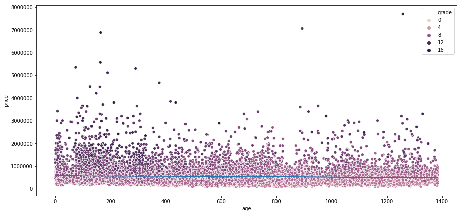

```
[-56.5464351]
```

```python
xax = 'age'
yax = 'price'

lm = LinearRegression()
X = df[xax].values.reshape(-1, 1)
y = df[yax].values
reg = lm.fit(X, y )

fig, ax = plt.subplots(figsize=(15,7))
ax = sns.scatterplot(x=xax, y=yax, data=df, hue = 'grade', sizes = 1)
plt.plot(X , reg.coef_ * X + reg.intercept_)
plt.show()
print(reg.coef_)
```

How does the price vary with age?

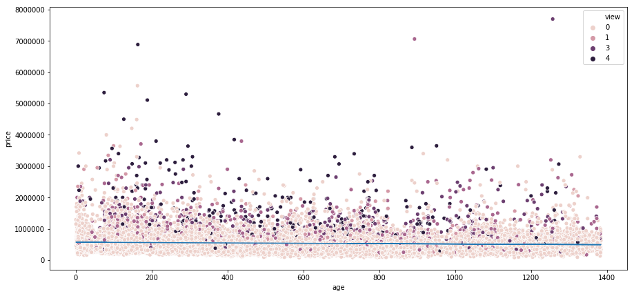

```python
lm = LinearRegression()
X = df["age"].values.reshape(-1, 1)
y = df['price'].values
reg = lm.fit(X, y )

fig, ax = plt.subplots(figsize=(15,7))
ax = sns.scatterplot(x="age", y="price", hue = 'view',  data=df, sizes = 1)
plt.plot(X , reg.coef_ * X + reg.intercept_)
plt.show()
```

We can see that the price of these homes does not decpreciate that much over time.

In conclusion:

If you wish to model the behavior of this data using linear regression, then you should find combinations of variables that increases the correlation with the target variable that you wish to predict.

Example: sqft_living * grade produces a data spread that better predicts the price of homes. This also follows from the fact that you are using more data in your prediction. If you don't know the grade of the home then this model wouldn't help you.

Using variables in the dataset we can isolate particular types of homes to analyze more closely, to see if statements that are true about particular groups are also true for the entire dataset.

Analyzing the relationship among variables can give insight into the very meaning of the data itself.

Example: By plotting the price versus the condition we see that it has the shape of a normal distribution. (There are most likely methods to find a distribution function that best models the data.) This by itself isn't too odd, but when condition versus age is shown our linear regression shows that there is a positive trend between age and condition.

# Candidates for future study

I have just started using folium, but as you can see we can alredy get a since of the distribution of home prices and have a better understanding of what may cause houses to be priced differently based on location.

```python
#folium is awesome
df = pd.read_csv('house_data.csv')

#I don't know if this is something you would be interested in.
m = folium.Map(location=list(df[['lat','long']].loc[0].values),
                        zoom_start = 12)

# mark each station as a point
for index, row in df[0:1000].iterrows():
    folium.CircleMarker([row['lat'], row['long']],
                        radius=3,
                        popup=str(row['price']),
                        fill_color="#3db7e4", # divvy color
                       ).add_to(m)

# convert to (n, 2) nd-array format for heatmap
stationArr = df[0:100][['lat', 'long']].values

# plot heatmap
m.add_child(plugins.HeatMap(stationArr, radius=3))
m
```

[interactive chart not shown]